# Exploring ordination options

Robyn Seymour-Jones

09/12/2020

## 1. Introduction

I want to perform an ordination on my diatom results to pick out the main variation in the diatom assemblage throughout my record and to see if I can find out what might be driving this variation. I don’t have any environmental data so I won’t be trying to fit any known variables to the ordination. Instead, I will use knowledge of the environmental preferences of the taxa along the gradients to interpret what environmental variables the gradients could represent. Therefore, I will only be looking into unconstrained ordination methods.

There are several options to decide upon when running the ordination:

1. Should the raw diatom counts be transformed? If so, which transformation should be used?
2. Should the diatom data be scaled to unit variance (i.e. standardised)?
3. Should the ordination be performed on all taxa or only abundant taxa (e.g. taxa present at ≥4% in at least one sample)? If performing on only abundant taxa, should the relative abundance be calculated from a sum of all taxa or only those abundant taxa?
4. What type of ordination should be performed? I have already decided I need to use unconstrained ordination techniques. But I also need to decide on the type of ordination to use based on the distributions of the species data.

## 2. Set up

The data are imported with the [manipulate script](https://github.com/robynfsj/phd-ioannina-long-record/blob/master/scripts/02-manipulate.R). I will need the data frames in the **taxa** list. I will also need the depths data frame in the **imported** list.

```r
library(ggplot2)
library(patchwork)
source("scripts/02-manipulate.R")
```

## 3. Data preparation method

The dataframes have sample_no as the first variable and still contain samples within which no diatoms were counted (as well as an outlier where diatoms were present, but only 100 were counted). These must be removed for ordination. A function is created so that the original dataframes can remain in a consistent format and so that I always know that any dataframe I come to use will have sample_no as the first variable. The function removes samples with no diatoms and moves sample_no to row names so that this information is preserved after ordination.

```r
ord_data <- function(df) {
  df %>%
    filter(sample_no != "189" & rowSums(.[, -1]) > 0) %>%
    column_to_rownames("sample_no")
}
```

## 4. Addressing my questions

### Decision 1: Should the raw diatom counts be transformed? And if so, which transformation should be used?

Legendre and Borcard (2018:1821) state that “[e]cologists have long known that untransformed (site × species) community composition data should not be analysed using the Euclidean distance, or through methods of multivariate analysis that preserve the Euclidean distance, such as principal component analysis and redundancy analysis, where calculations are carried out in Euclidean space”. Therefore, if I am to perform a principal component analysis (PCA), it is clear that I need to transform the data prior to the analysis.

Transforming the data reduces the skewness of a species distribution and helps to address the double zero problem (the unwanted situation where the absence of a species from two sites is interpreted as an indication of similarity between the sites). Through doing this, it makes the data suitable for analysis using linear methods (such as PCA) within Euclidean space.

I don’t think I am that interested in placing higher weightings on rare taxa as I am looking to find the main variation within the data. If the record is dominated by one taxon (as I know it is), I want the results of the ordination to show this. However, I don’t want the absence of a species from two samples to indicate similarity.

#### Transformation: relative abundances

I have already transformed the data into percentage relative abundances as part of the [manipulate script](https://github.com/robynfsj/phd-ioannina-long-record/blob/master/scripts/02-manipulate.R). These are the data frames in the taxa list with the rel_ab prefix. Note that I perform these analyses on abundant taxa only with percentages calculated based on a sum of all taxa counted in a sample. This is so that the analyses produce cleaner plots with fewer taxa displayed. I will address whether this is the right thing to do in later sections of this document.

##### DCA

```r
untransformed_dca <- decorana(ord_data(taxa$rel_ab_4))
untransformed_dca
```

```
##
## Call:
## decorana(veg = ord_data(taxa$rel_ab_4))
##
## Detrended correspondence analysis with 26 segments.
## Rescaling of axes with 4 iterations.
##
##                   DCA1    DCA2    DCA3    DCA4
## Eigenvalues     0.1774 0.12187 0.06592 0.05696
## Decorana values 0.2671 0.09288 0.05169 0.03526
## Axis lengths    1.9914 2.04005 1.03483 0.89091
```

DCA1 axis length is <2.5 so linear methods such as PCA are appropriate (Legendre & Birks, 2012).

##### PCA

```r
untransformed_pca <- rda(ord_data(taxa$rel_ab_4))
untransformed_pca
```

```
## Call: rda(X = ord_data(taxa$rel_ab_4))
##
##               Inertia Rank
## Total             409
## Unconstrained     409   27
## Inertia is variance
##
## Eigenvalues for unconstrained axes:
##    PC1    PC2    PC3    PC4    PC5    PC6    PC7    PC8
## 262.40  64.84  39.94  11.33   6.59   4.60   3.78   2.32
## (Showing 8 of 27 unconstrained eigenvalues)
```

```r
# Proportion of variance explained by PC1 and PC2
sum((as.vector(untransformed_pca$CA$eig) / sum(untransformed_pca$CA$eig))[1:2]) * 100
## [1] 80.00349

# Proportion of variance explained by PC1
sum((as.vector(untransformed_pca$CA$eig) / sum(untransformed_pca$CA$eig))[1]) * 100
## [1] 64.15053

# Proportion of variance explained by PC2
sum((as.vector(untransformed_pca$CA$eig) / sum(untransformed_pca$CA$eig))[2]) * 100
## [1] 15.85296
```

##### Plot of PC1 by core depth

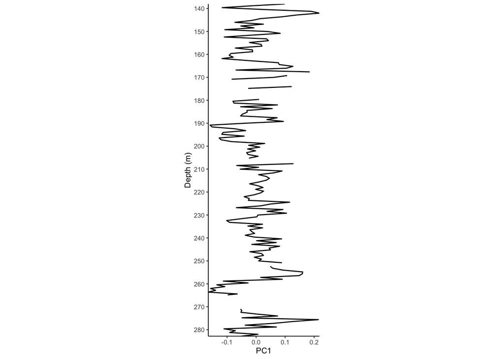

```r
untransformed_pc1_scrs <- data.frame(scores(untransformed_pca,
                                            choices = 1, # select only PC1
                                            display = "sites",
                                            scaling = 0)) %>%
  mutate(sample_no = as.numeric(row.names(.))) %>%
  right_join(imported$depths)

plot_untransformed_pc1 <- ggplot(untransformed_pc1_scrs, aes(x = depth, y = PC1)) +
  geom_line() +
  coord_flip() +
  scale_x_reverse(expand = c (0, 0), breaks = seq(130, 290, 10)) +
  scale_y_continuous(expand = c(0, 0)) +
  labs(x = "Depth (m)") +
  theme_classic(8) +
  theme(aspect.ratio = 3)

plot_untransformed_pc1
```

##### Quick ordination biplots

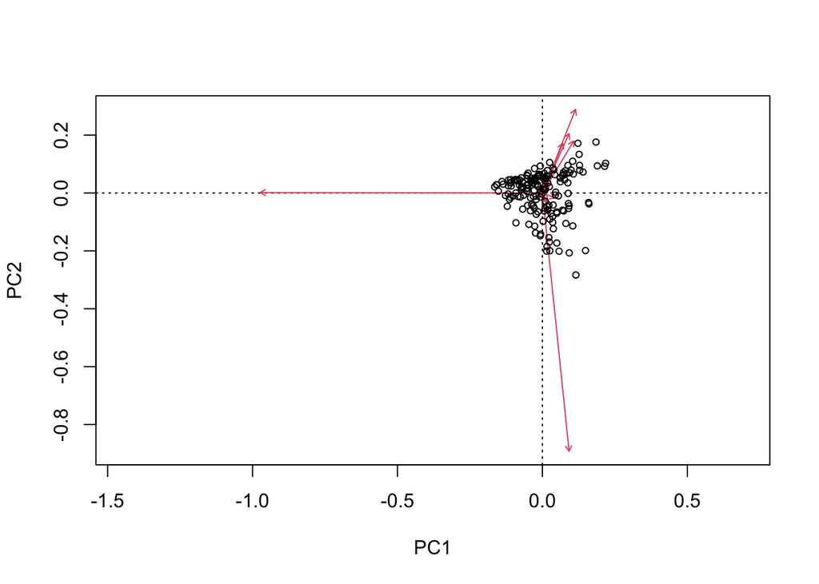

```r
biplot(untransformed_pca, scaling = "none")
```

Scale the species in order to display the distribution of the sites more clearly.

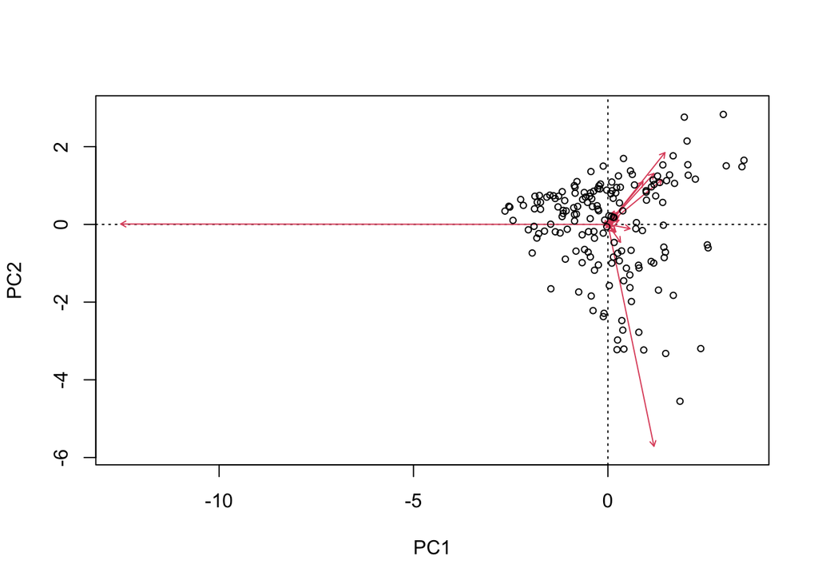

```r
biplot(untransformed_pca, scaling = "species")
```

##### Evaluation

According to Legendre and Gallagher (2001), a species profile transformation is not the best transformation to use as it still considers double zeros to be an indicator of similarity.

The sites are spread out oddly, forming a sort of wedge shape pointing towards the left of the plot and two trailing tail shapes on the right side of the plot, which I think might be the horseshoe effect. I don’t really understand the horseshoe effect except that it isn’t desirable. I don’t know if the horseshoe shape is always vertical or if it can appear horizontal as I think it does here.

There are two species that stand out as driving the variation across the samples. I have plotted the quick biplots as points above so they are easy to read but plotting with text shows these species are *P. ocellata* and *P. minuscula*, which is what I expected as *P. ocellata* dominates my record.

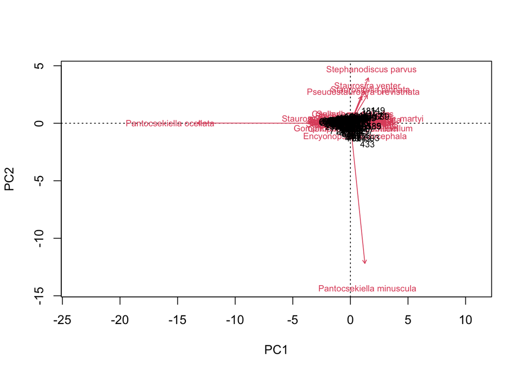

```r
biplot(untransformed_pca, scaling = "sites", type = "text")
```

#### Transformation: Hellinger (square root of relative abundances)

Square root transformation “lowers the importance of the most abundant species, which may grow exponentially when they encounter favourable conditions” (Legendre & Birks, 2012:216).

##### Square-root transform data

```r
sqrt_rel_ab_4 <- ord_data(taxa$rel_ab_4) %>%
  sqrt()
```

##### DCA

```r
sqrt_dca <- decorana(sqrt_rel_ab_4)
sqrt_dca
```

```
##
## Call:
## decorana(veg = sqrt_rel_ab_4)
##
## Detrended correspondence analysis with 26 segments.
## Rescaling of axes with 4 iterations.
##
##                   DCA1    DCA2    DCA3    DCA4
## Eigenvalues     0.1492 0.08724 0.05487 0.05982
## Decorana values 0.1524 0.07827 0.05151 0.04394
## Axis lengths    1.7056 1.38091 1.20358 1.30706
```

DCA1 axis length is <2.5 so linear methods such as PCA are appropriate (Legendre & Birks, 2012).

##### PCA

```r
sqrt_pca <- rda(sqrt_rel_ab_4)
sqrt_pca
```

```
## Call: rda(X = sqrt_rel_ab_4)
##
##               Inertia Rank
## Total           13.91
## Unconstrained   13.91   27
## Inertia is variance
##
## Eigenvalues for unconstrained axes:
##   PC1   PC2   PC3   PC4   PC5   PC6   PC7   PC8
## 3.555 2.158 1.692 1.030 0.751 0.587 0.473 0.413
## (Showing 8 of 27 unconstrained eigenvalues)
```

```r
# Proportion of variance explained by PC1 and PC2
sum((as.vector(sqrt_pca$CA$eig) / sum(sqrt_pca$CA$eig))[1:2]) * 100
## [1] 41.06445

# Proportion of variance explained by PC1
sum((as.vector(sqrt_pca$CA$eig) / sum(sqrt_pca$CA$eig))[1]) * 100
## [1] 25.55478

# Proportion of variance explained by PC2
sum((as.vector(sqrt_pca$CA$eig) / sum(sqrt_pca$CA$eig))[2]) * 100
## [1] 15.50968
```

##### Plot of PC1 by core depth

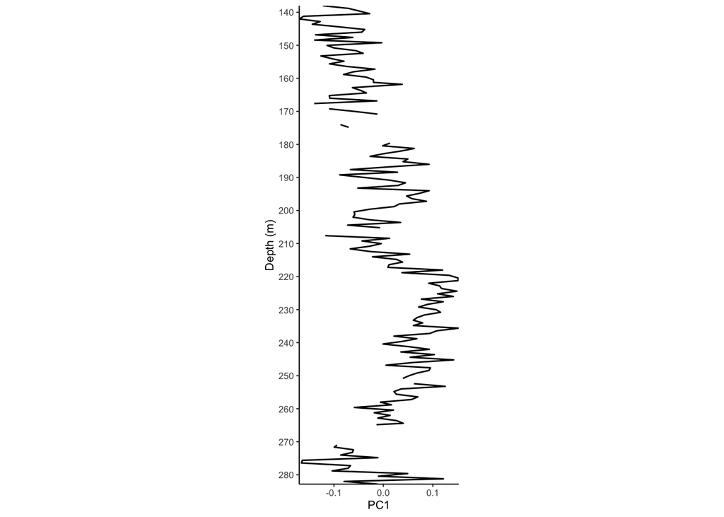

```r
sqrt_pc1_scrs <- data.frame(scores(sqrt_pca,
                                   choices = 1, # select only PC1
                                   display = "sites",
                                   scaling = 0)) %>%
  mutate(sample_no = as.numeric(row.names(.))) %>%
  right_join(imported$depths)

plot_sqrt_pc1 <- ggplot(sqrt_pc1_scrs, aes(x = depth, y = PC1)) +
  geom_line() +
  coord_flip() +
  scale_x_reverse(expand = c (0, 0), breaks = seq(130, 290, 10)) +
  scale_y_continuous(expand = c(0, 0)) +
  labs(x = "Depth (m)") +
  theme_classic(8) +
  theme(aspect.ratio = 3)

plot_sqrt_pc1
```

##### Quick ordination biplot

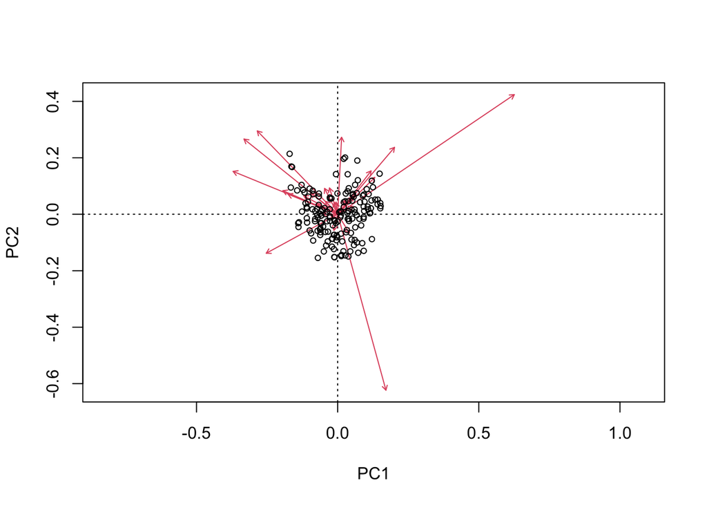

```r
biplot(sqrt_pca, scaling = "none")
```

Scale the species in order to display the distribution of the sites more clearly.

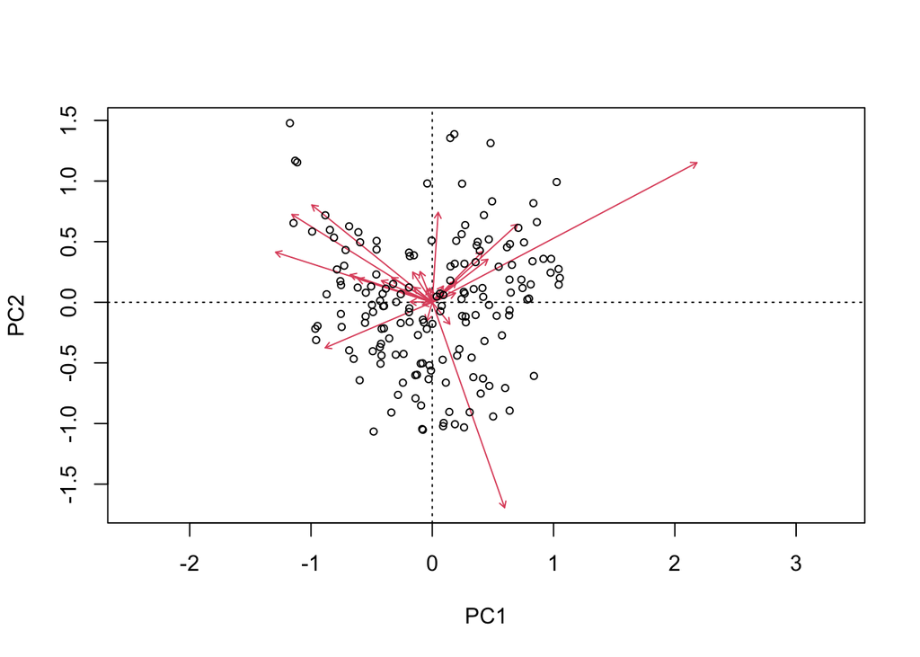

```r
biplot(sqrt_pca, scaling = "species")
```

##### Evaluation

Legendre and Gallagher (2001) recommend this transformation (or the chord transformation) for species abundance data where it is not desired to give large weightings to rare species. According to what I have read, this should be the transformation most suitable for my data.

PC1 only explains 26% of the variance, which is not ideal when I want to plot this alongside my stratigraphic diagram as it doesn’t explain much.

The biplot looks ok with sites spread out nicely, although there is a slight horseshoe effect. Two species drive more variation than the rest. Again these are *P. ocellata* and *P. minuscula*:

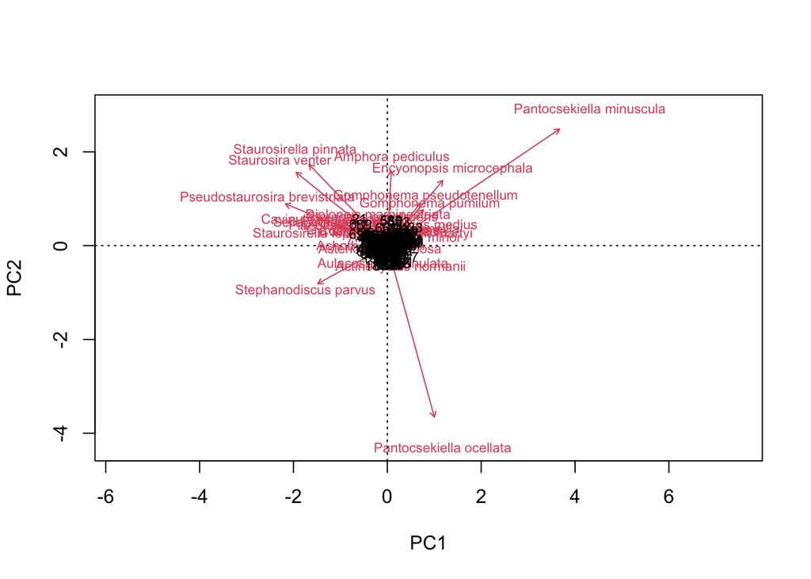

```r
biplot(sqrt_pca, scaling = "sites", type = "text")
```

##### Comparison of transformations

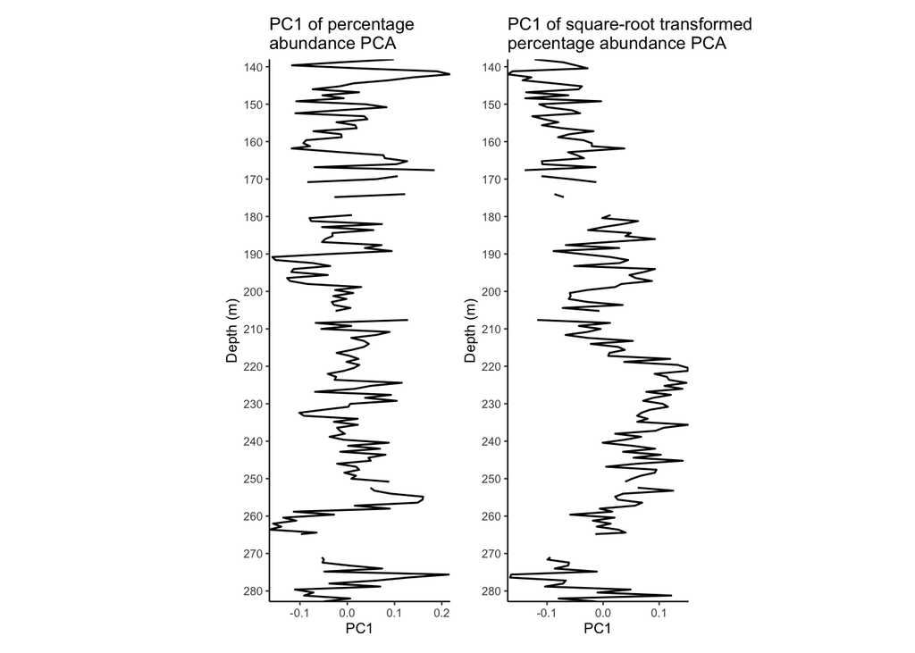

```r
plot_untransformed_pc1 +
  labs(title = "PC1 of percentage\nabundance PCA") +
plot_sqrt_pc1 +
  labs(title = "PC1 of square-root transformed\npercentage abundance PCA")
```

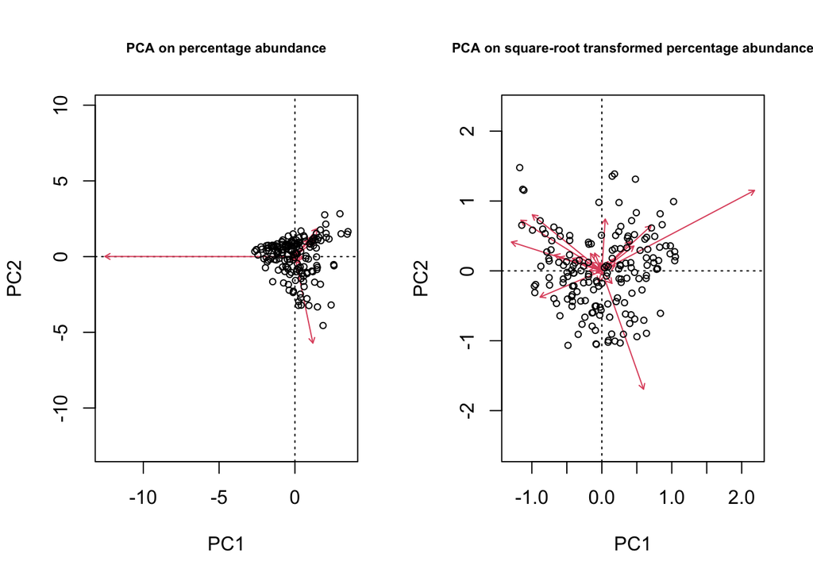

```r
par(mfrow = c(1, 2))

biplot(untransformed_pca,
       scaling = "species",
       main = "PCA on percentage abundance",
       cex.main = 0.7)

biplot(sqrt_pca,
       scaling = "species",
       main = "PCA on square-root transformed percentage abundance",
       cex.main = 0.7)
```

The biplot for the square-root transformation looks much nicer than the biplot for the percentage abundance data. The samples are more spread out and the species arrows are more similar in length to each other, rather than there being two arrows that were much longer than the others. The latter demonstrates the impact of square-root transforming the percentage abundances, giving less weight to very abundant taxa.

### Decision 2: Should the diatom data be scaled to unit variance (i.e. standardised)?

Standardisation is a special form of transformation where the variables are transformed to have a mean of 0 and a variance (or sometimes a standard deviation) of 1. This puts different variables on the same scale. When working with physical, chemical or geological variables, it is standard practice to standardise these variables prior to an ordination as they are measured in different units. If this step is not done then a variable that is measured in larger numbers is weighted more heaviliy in the ordination than a variable measured in smaller numbers. For example, lake temperature measured in degrees celcius might fall within the range of 5 to 15 degrees but depth could be several hundreds of meters. If we want to give the same weighting to these variables so they equally contribute to the ordination then they would need to be standardised. However, when working with species variables, these are all clearly measured in the same unit so there is no need to standardise. But, if the raw counts are transformed into relative proportions (and the ordination is run on all taxa, not only on the abundant ones), then this is effectively a standardisation.

My question of standardisation here has developed slightly and is only relevant if I decide to run the ordination on only abundant taxa. In this situation, do I perform the ordination on percentages of the abundant taxa based on a sum of all taxa or the percentages based on a sum of only those abundant taxa? This is a similar situation to when I was trying to decide on how to run my cluster analysis (see decision 5 of [Exploring zonation options](https://robynfsj.github.io/phd-ioannina-long-record/exploring-zonation-options.html)).

```r
# Prepare data for analysis
abundant_taxa <- taxa$counts %>%
  # isolate taxa present at ≥4 %
  transmute(
    sample_no = sample_no,
    select(., all_of(abundant_taxa(taxa$rel_ab, 4)))
  ) %>%
  # convert to proportion based on only these abundant taxa
  mutate(
    sample_no = sample_no,
    decostand(select(., -sample_no),
              method = "total",
              na.rm = "TRUE")
  )
```

I will look at this for both percentage abundance data and for square-root transformed percentage abundance data as I still don’t know which I will be using yet.

#### Transformation: relative abundances

```r
ab_t <- ord_data(abundant_taxa)
```

##### DCA

```r
ab_t_dca <- decorana(ab_t)
ab_t_dca
```

```
##
## Call:
## decorana(veg = ab_t)
##
## Detrended correspondence analysis with 26 segments.
## Rescaling of axes with 4 iterations.
##
##                   DCA1   DCA2    DCA3    DCA4
## Eigenvalues     0.1770 0.1218 0.07053 0.05612
## Decorana values 0.2659 0.0935 0.05262 0.03521
## Axis lengths    1.9907 1.9805 1.04008 0.90533
```

DCA axis 1 length is <2.5 so linear methods are appropriate.

```r
ab_t_pca <- rda(ab_t)
ab_t_pca
```

```
## Call: rda(X = ab_t)
##
##               Inertia Rank
## Total         0.04257
## Unconstrained 0.04257   26
## Inertia is variance
##
## Eigenvalues for unconstrained axes:
##      PC1      PC2      PC3      PC4      PC5      PC6      PC7      PC8
## 0.024909 0.008083 0.004739 0.000951 0.000815 0.000564 0.000492 0.000307
## (Showing 8 of 26 unconstrained eigenvalues)
```

##### PCA

```r
# Proportion of variance explained by PC1 and PC2
sum((as.vector(ab_t_pca$CA$eig) / sum(ab_t_pca$CA$eig))[1:2]) * 100
## [1] 77.49265

# Proportion of variance explained by PC1
sum((as.vector(ab_t_pca$CA$eig) / sum(ab_t_pca$CA$eig))[1]) * 100
## [1] 58.50702

# Proportion of variance explained by PC2
sum((as.vector(ab_t_pca$CA$eig) / sum(ab_t_pca$CA$eig))[2]) * 100
## [1] 18.98564
```

The proportion expained by PC1 and PC2 is 77% so less than the 80% explained by the first two axes when the percentages were calculated from a sum of all taxa. Proportion explained by PC1 for that analysis was 64%, higher than the 59% explained here.

##### PC1 axis scores

```r
ab_t_pc1_scrs <- data.frame(scores(ab_t_pca,
                              choices = 1, # select only PC1
                              display = "sites",
                              scaling = 0)) %>%
  mutate(sample_no = as.numeric(row.names(.))) %>%
  right_join(imported$depths)
```

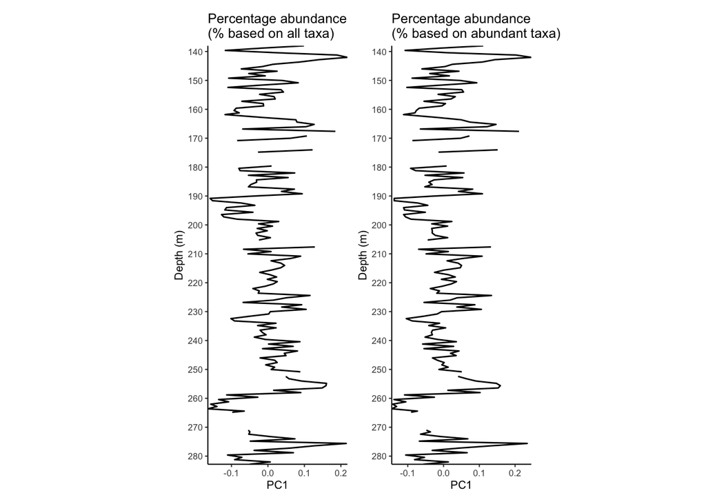

```r
plot_ab_t_pc1 <- ggplot(ab_t_pc1_scrs, aes(x = depth, y = PC1)) +
  geom_line() +
  coord_flip() +
  scale_x_reverse(expand = c (0, 0), breaks = seq(130, 290, 10)) +
  scale_y_continuous(expand = c(0, 0)) +
  labs(x = "Depth (m)") +
  theme_classic(8) +
  theme(aspect.ratio = 3)

plot_untransformed_pc1 +
  labs(title = "Percentage abundance\n(% based on all taxa)") +
plot_ab_t_pc1 +
  labs(title = "Percentage abundance\n(% based on abundant taxa)")
```

The PC1 axis scores are very similar. There are a few differences that can be seen if you look very carefully. These are most noticable at around 190 m to 210 m depth, although there are some other slight variations in other places.

##### Biplots

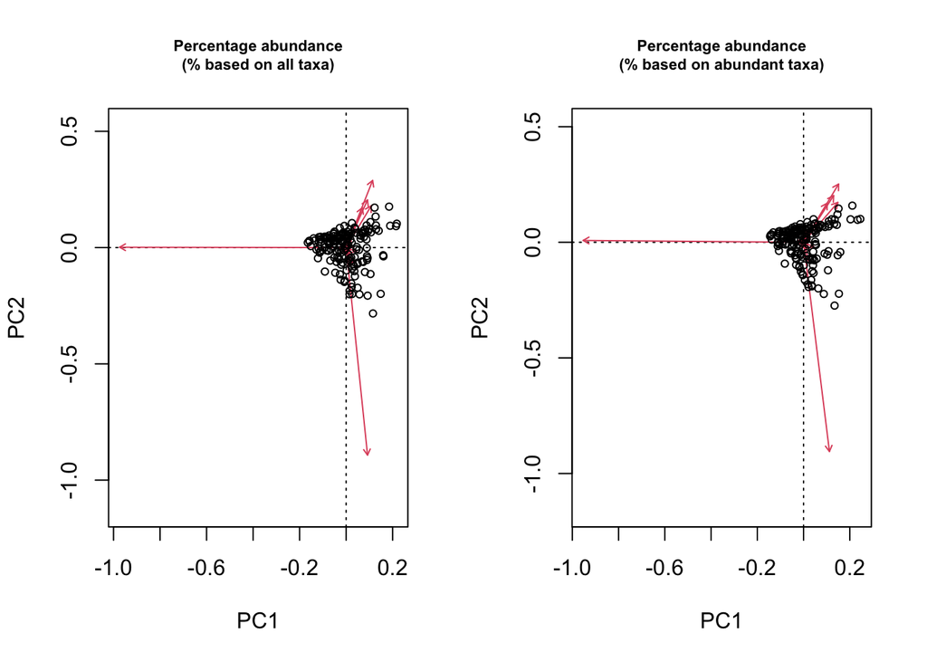

```r
par(mfrow = c(1, 2))

biplot(untransformed_pca,
       scaling = "none",
       main = "Percentage abundance\n(% based on all taxa)",
       cex.main = 0.7)

biplot(ab_t_pca,
       scaling = "none",
       main = "Percentage abundance\n(% based on abundant taxa)",
       cex.main = 0.7)
```

If anything, there is a stronger arch effect for the percentages based on a sum of only the abundant taxa.

#### Transformation: Hellinger (square root of relative abundances)

```r
ab_t_sqrt <- ord_data(abundant_taxa) %>%
  sqrt()
```

##### DCA

```r
ab_t_sqrt_dca <- decorana(ab_t_sqrt)
ab_t_sqrt_dca
```

```
##
## Call:
## decorana(veg = ab_t_sqrt)
##
## Detrended correspondence analysis with 26 segments.
## Rescaling of axes with 4 iterations.
##
##                   DCA1    DCA2    DCA3    DCA4
## Eigenvalues     0.1494 0.08778 0.05309 0.06006
## Decorana values 0.1527 0.07798 0.05145 0.04395
## Axis lengths    1.7013 1.38473 1.19692 1.20920
```

DCA1 <2.5 so linear methods are appropriate.

##### PCA

```r
ab_t_sqrt_pca <- rda(ab_t_sqrt)
ab_t_sqrt_pca
```

```
## Call: rda(X = ab_t_sqrt)
##
##               Inertia Rank
## Total          0.1539
## Unconstrained  0.1539   27
## Inertia is variance
##
## Eigenvalues for unconstrained axes:
##     PC1     PC2     PC3     PC4     PC5     PC6     PC7     PC8
## 0.03984 0.02336 0.01809 0.01146 0.00830 0.00647 0.00534 0.00461
## (Showing 8 of 27 unconstrained eigenvalues)
```

```r
# Proportion of variance explained by PC1 and PC2
sum((as.vector(ab_t_sqrt_pca$CA$eig) / sum(ab_t_sqrt_pca$CA$eig))[1:2]) * 100
## [1] 41.07512

# Proportion of variance explained by PC1
sum((as.vector(ab_t_sqrt_pca$CA$eig) / sum(ab_t_sqrt_pca$CA$eig))[1]) * 100
## [1] 25.89358

# Proportion of variance explained by PC2
sum((as.vector(ab_t_sqrt_pca$CA$eig) / sum(ab_t_sqrt_pca$CA$eig))[2]) * 100
## [1] 15.18154
```

The percentages are very similar as for when the percentage abundance was based on a sum of all taxa.

##### PC1 axis scores

```r
ab_t_sqrt_pc1_scrs <- data.frame(scores(ab_t_sqrt_pca,
                              choices = 1, # select only PC1
                              display = "sites",
                              scaling = 0)) %>%
  mutate(sample_no = as.numeric(row.names(.))) %>%
  right_join(imported$depths)
```

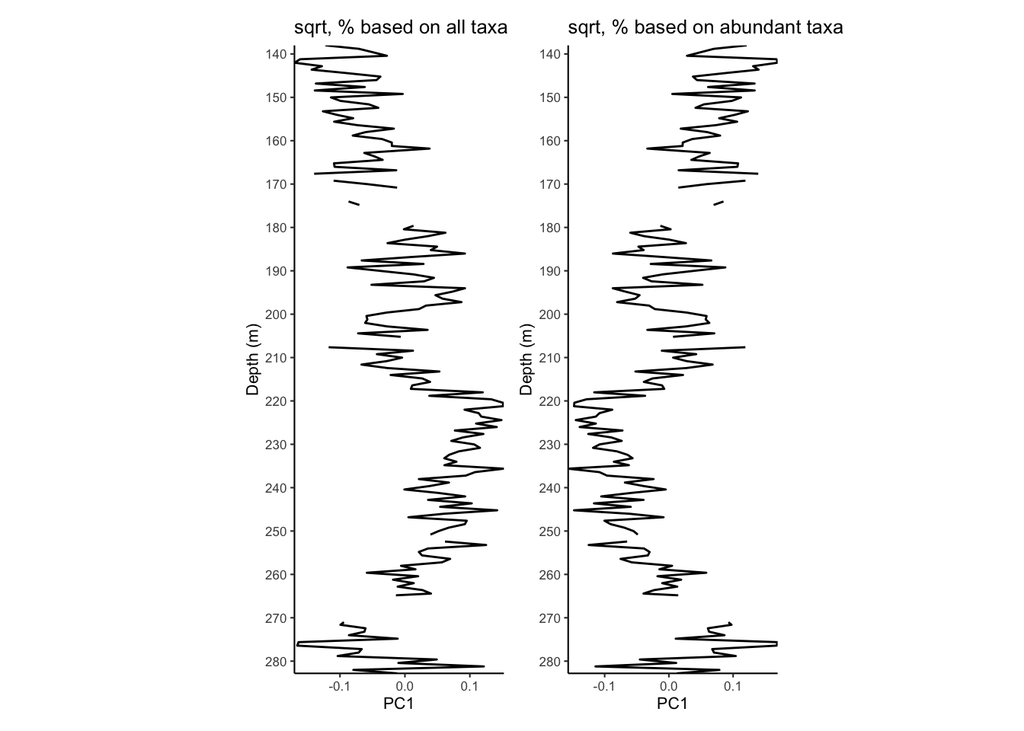

```r
plot_ab_t_sqrt_pc1 <- ggplot(ab_t_sqrt_pc1_scrs, aes(x = depth, y = PC1)) +
  geom_line() +
  coord_flip() +
  scale_x_reverse(expand = c (0, 0), breaks = seq(130, 290, 10)) +
  scale_y_continuous(expand = c(0, 0)) +
  labs(x = "Depth (m)") +
  theme_classic(8) +
  theme(aspect.ratio = 3)

plot_sqrt_pc1 +
  labs(title = "sqrt, % based on all taxa") +
plot_ab_t_sqrt_pc1 +
  labs(title = "sqrt, % based on abundant taxa")
```

There isn’t much difference between the two, although it has flipped the results. If I reverse the PC1 axis values for one of them then it is possible to see just how similar they are:

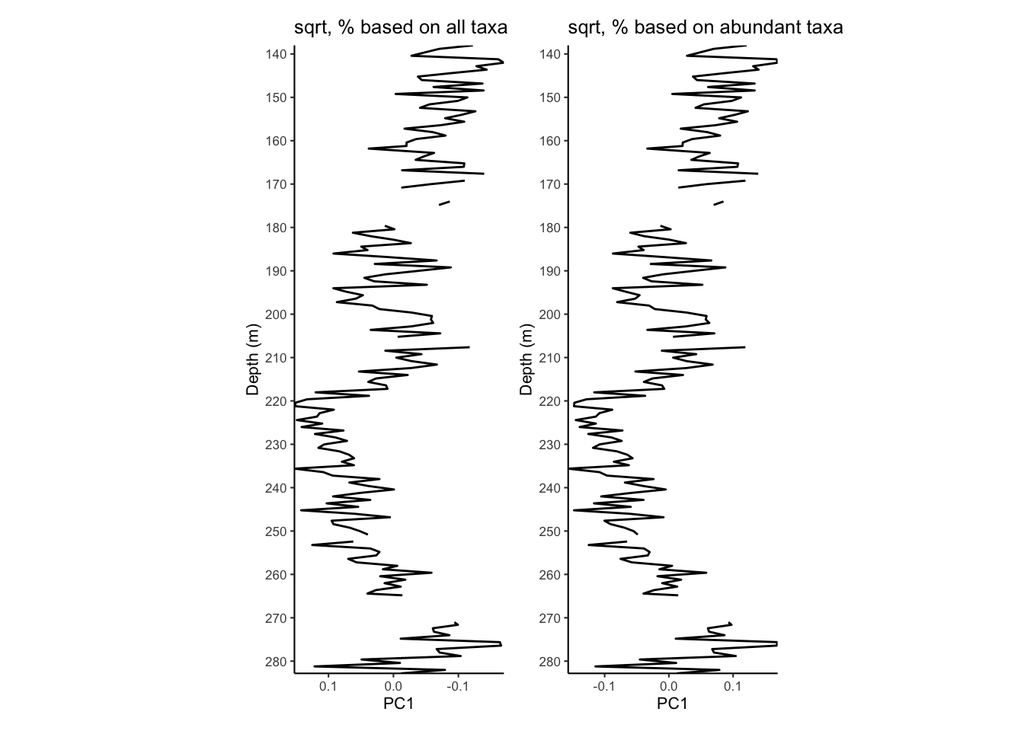

```r
plot_sqrt_pc1_rev <- ggplot(sqrt_pc1_scrs, aes(x = depth, y = PC1)) +
  geom_line() +
  coord_flip() +
  scale_x_reverse(expand = c (0, 0), breaks = seq(130, 290, 10)) +
  scale_y_reverse(expand = c(0, 0)) +
  labs(x = "Depth (m)") +
  theme_classic(8) +
  theme(aspect.ratio = 3)


plot_sqrt_pc1_rev +
  labs(title = "sqrt, % based on all taxa") +
plot_ab_t_sqrt_pc1 +
  labs(title = "sqrt, % based on abundant taxa")
```

The are almost identical. It is possible to see a very slight difference in the values at around 220 m depth where the values do not quite reach the y-axis on the right-hand plot.

##### Biplots

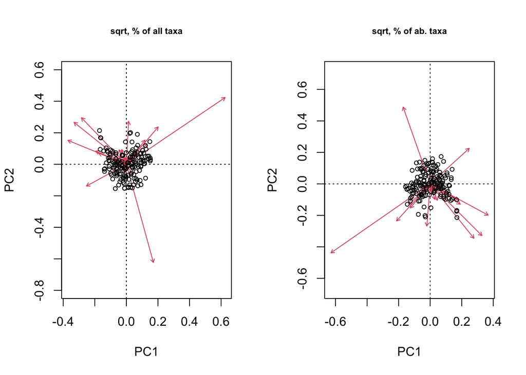

```r
par(mfrow = c(1, 2))

biplot(sqrt_pca,
       scaling = "none",
       main = "sqrt, % of all taxa",
       cex.main = 0.7)

biplot(ab_t_sqrt_pca,
       scaling = "none",
       main = "sqrt, % of ab. taxa",
       cex.main = 0.7)
```

Plots are very similar but rotated 180 degrees.

## References

Legendre, P & Birks, H. J. B. (2012) From classical to canonical ordination. In Birks, H. J. B., Lotter, A. F., Juggins, S. & Smol, J. P. (eds) *Tracking* *Environmental Change using Lake Sediments. Volume 5: Data Handling and* *Numerical Techniques*. Dordrecht: Springer. https://doi.org/10.1007/978-94-007-2745-8_8

Legendre, P. & Borcard, D. (2018) Box–Cox-chord transformations for community composition data prior to beta diversity analysis. *Ecography*, 41, 1820–1824. https://doi.org/10.1111/ecog.03498